# Exponential Distribution and Central Limit Theorem

**Author Name: Longguang Qin**

This document is for illustration of Central Limit Theorem via simulation of exponential distribution. Using R function *rexp*, the distributions of a large collection of averages of 40 exponentials. Then, through investigating the sample mean, the sample variance and the type of that distribution, we could test whether Central Limit Theorem is valid for exponential distribution.

## Simulation

This is an example of the distributions of a large collection of averages of 40 exponentials:

```r
lambda <- 0.2
mns <- NULL
for (i in 1:1000) mns <- c(mns, mean(rexp(40, lambda)))
hist(mns, xlab = "the sample mean", main = "Histogram of a large collection of averages of 40 exponentials")
```

[output not shown]

## Sample Mean Vs Theoretic Mean

```r
hist(mns, xlab = "the sample mean", main = "Histogram of a large collection of averages of 40 exponentials")
```

[output not shown]

```r
sp_mn <- mean(mns)
sp_mn #the mean of the distribution of a large collection of averages of 40 exponentials.
```

```
## [1] 4.96662
```

**the theoretic mean is:**

```
## [1] 5
```

**the result of comparision**: The sample mean and the theoretic mean are almost the same.

## Sample variance Vs Theoretic variance

```r
hist(mns, xlab = "the sample mean", main = "Histogram of a large collection of averages of 40 exponentials")
```

[output not shown]

```r
sp_variance <- var(mns)
sp_variance #the variance of the distribution of a large collection of averages of 40 exponentials.
```

```
## [1] 0.6126693
```

**The theoretic variance is:**

```
## [1] 0.625
```

**the result of comparision**: The sample variance and the theoretic variance are almost the same.

## Is the distribution of sample mean is normal?

**Normalize the distribution of the sample mean:**

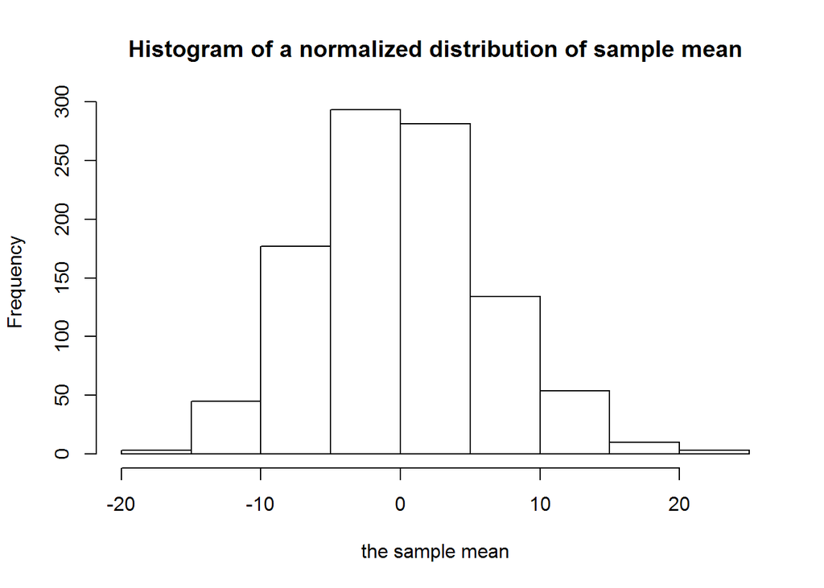

```r
SE <- sqrt(var(mns)/40)
mns_nm <-(mns-mean(mns))/SE
hist(mns_nm, xlab = "the sample mean", main = "Histogram of a normalized distribution of sample mean")
```

**The distribution of a large collection of random exponentials:**

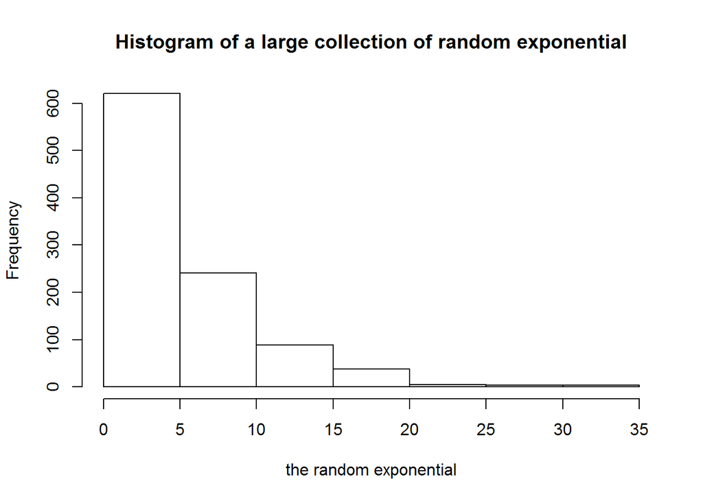

```r
exp <- rexp(1000, lambda)
hist(exp, xlab = "the random exponential", main = "Histogram of a large collection of random exponential")
```

**Result:**the distribution of a large collection of random exponentials is definitely not a normal distribution; however, when we randomly draw 40 samples of that distribution, take the sample means and normalize those averages, the distribution of those averages is centered around 0 and has a shape of bell curve, shown as Histogram of a normalized distribution of sample mean. Therefore, the distribution is approximately normal.